# Vehicle Fuel Economy Analysis

### Neha Veeragandham and Clara Hong

## Introduction:

Cars form an essential component of modern life, delivering substantial convenience and adaptability. They enable people to journey to any location they desire, at any time they like. Beyond their personal transportation capabilities, they also have a significant role in commercial transport. They facilitate the movement of goods and services across long distances in a punctual and efficient manner. The prevalence of automobiles in our daily lives makes it crucial to comprehend the fuel emissions each vehicle emits for responsible consumer decision-making and environmental protection.

In the process of buying a vehicle, it is vital to evaluate its fuel economy rating, which quantifies the car's fuel consumption efficiency. This rating serves as a metric of long-term cost savings and also as an indicator of the car's environmental impact over its entire lifespan. As consumers become increasingly eco-aware, selecting a vehicle with a superior fuel economy rating can notably lessen one's carbon imprint and support broader initiatives to fight climate change.

With transportation being one of the largest sources of greenhouse gas emissions, the long-term environmental impact of cars is a serious concern. Understanding the economy of different vehicles helps consumers make informed decisions that can lead to a reduction in harmful emissions, as well as help them save money in the long run. By opting for vehicles with higher fuel efficiency, individuals can save significant amounts of money through tax reductions, and lower gas prices.

This project aims to provide insights that can help consumers make informed decisions and understand the broader implications of their vehicle choices.

Learn more about the importance of fuel economy and how it impacts the environment and consumer costs on the [EPA Fuel Economy website](https://www.fueleconomy.gov/).

```python
#imports
import pandas as pd
import matplotlib.pyplot as plt
import seaborn as sns
import numpy as np
from scipy.stats import ttest_ind
from sklearn.model_selection import train_test_split
from sklearn.preprocessing import LabelEncoder, StandardScaler, OneHotEncoder
from sklearn.metrics import mean_squared_error, r2_score
from sklearn.linear_model import SGDRegressor

'''
DATA COLELCTION (DATASET FROM KAGGLE)
'''

data = pd.read_csv('fuel.csv')

data.drop_duplicates(inplace=True)

data['year'] = data['year'].astype(int) #convert year to int value
```

## Data Collection:

**The data used in this project is sourced from [Kaggle](https://www.kaggle.com/), a subsidiary of Google which allows users to access a wide range of datasets. Specifically, we chose a dataset called “Vehicle Fuel Economy,” which is highly relevant to our exploration of vehicle choices and their fuel economy scores. The dataset includes information about vehicle specifications, fuel efficiency, and their environmental impact.

We obtained the data by directly downloading it from Kaggle ([here](https://www.kaggle.com/datasets/sahirmaharajj/fuel-economy/data)). The data is given in the form of a CSV file. After downloading, we used the [Pandas](https://pandas.pydata.org/) library to convert the dataset into a Pandas DataFrame.**

## Data Cleaning/Processing

The initial dataset contains information on 38113 vehicles, with 81 different features ranging from the years 1983 to 2017.

First we removed duplicate entries to prevent any distortion in our results and conclusions. Then the year column, which represents the year a vehicle model was released, is converted into the integer type to ensure that numerical operations can be performed smoothly later.

Next, we performed several steps to clean our dataset to keep only the columns and rows which had relevant information. We removed unnecessary columns and dropped columns with low variance. Columns with low variance aren’t useful for analysis because they don’t provide any significant information that can help distinguish between different data points. Once this was done, we were left with the year, make, and model of each vehicle.

As well as a vehicle’s:

Lastly, we filtered out all rows that had invalid fuel economy scores, or a value of -1. The range for the fuel economy score is 1 - 10, with 1 being the worst and 10 being the best for fuel economy and greenhouse gas emissions.

Later in our analysis, we broadened the vehicle classes from 22 classes to 5 classes. As the original dataset had separated the car classes also by drive and size of the cars, this was redundant with the drive column. By decreasing the number of classes, it allows us to have larger sample sizes so we can get more stable and generalizable results.

```python
'''
REMOVE IRRELEVANT COLUMNS
'''
columns_to_drop = [
    'city_electricity_consumption', 'highway_electricity_consumption', 'combined_electricity_consumption',
    'city_utility_factor', 'highway_utility_factor', 'combined_utility_factor', 'electric_motor',
    'gasoline_electricity_blended_cd', 'vehicle_charger', 'alternate_charger', 'hours_to_charge_120v',
    'hours_to_charge_240v', 'hours_to_charge_ac_240v', 'alternative_fuel_technology', 'city_gasoline_consumption_cd', 'highway_gasoline_consumption_cd',
    'fuel_type_2', 'annual_consumption_in_barrels_ft2', 'tailpipe_co2_ft2',
    'combined_mpg_ft2', 'unrounded_combined_mpg_ft2', 'city_mpg_ft2', 'unrounded_city_mpg_ft2',
    'highway_mpg_ft2', 'unrounded_highway_mpg_ft2', 'my_mpg_data', 'range_ft2', 'city_range_ft2',
    'highway_range_ft2','x2d_passenger_volume', 'x2d_luggage_volume', 'x4d_passenger_volume',
    'x4d_luggage_volume', 'hatchback_passenger_volume', 'hatchback_luggage_volume', 'fuel_type_1',
    'unrounded_city_mpg_ft1', 'unrounded_highway_mpg_ft1', 'unrounded_combined_mpg_ft1',
    'unadjusted_city_mpg_ft2', 'unadjusted_highway_mpg_ft2', 'annual_fuel_cost_ft2',
    'ghg_score_alt_fuel', 'composite_city_mpg', 'composite_highway_mpg', 'composite_combined_mpg',
       'range_ft1', 'city_range_ft1', 'highway_range_ft1', 'save_or_spend_5_year', 'annual_consumption_in_barrels_ft1',
    'engine_index', 'tailpipe_co2_ft1', 'vehicle_id', 'city_mpg_ft1',
     'highway_mpg_ft1', 'unadjusted_city_mpg_ft1',
       'unadjusted_highway_mpg_ft1',  'tailpipe_co2_in_grams_mile_ft2', 'ghg_score', 'tailpipe_co2_in_grams_mile_ft1',
    'annual_fuel_cost_ft1', 'combined_gasoline_consumption_cd', 'combined_mpg_ft1'
]
# Drop the above columns as well as low variance columns
data.drop(columns=columns_to_drop, inplace=True)
low_variance_cols = [col for col in data.columns if data[col].nunique() <= 1]
data.drop(columns=low_variance_cols, inplace=True)
```

```python
'''
WE ARE LOOKING AT ONLY GAS CARS
'''
#we are not looking at the below types of vehicles
non_fuel_vehicle_types = ['Electricity', 'Regular Gas and Electricity', 'Premium Gas or Electricity']

# Filter out non-fuel vehicles
fuel_vehicles = data[~data['fuel_type'].isin(non_fuel_vehicle_types)]
```

## Exploratory Data Analysis/Visualization

We performed exploratory data analysis to understand the relationships between different variables and high vs. low fuel economy scores. To do this we generated descriptive statistics and visualized the data using various different types of graphs, each best suited for displaying the data at hand.

The variable that we focused on the most were the fuel economy scores, which represent the efficiency of a vehicle in terms of fuel consumption. Higher scores generally indicate more fuel-efficient vehicles.

Next, we standardized the data to better understand and compare the relationships between the variables with their fuel economy scores. The standardize_by_category function uses groupby to find the mean and standard deviation for the distinct groups in the class, transmission, drive, and fuel type columns. Once the two statistics were found, the fuel economy scores for each vehicle were standardized with their mean and standard deviation of their group. By standardizing the fuel economy score within each category it removes the bias of category specific differences. This makes the scores directly comparable.

The unstandardized plots show the raw fuel economy scores, which have varying scales and ranges. This makes comparing across categories challenging as it’s hard to account for category specific variations.

When comparing the average fuel economy scores by year, we found a surprising downward trend, as the years progressed. Despite advances in modern technology, the scores were gradually decreasing. To understand why this was happening, we modeled other variables against time, such as average fuel economy by transmission type, which showed that both automatic and manual transmissions were gradually decreasing in scores. This did not tell us much, so we modeled vehicle class distribution over time to see if there was an increase in vehicles that have low scores, pulling the yearly average down. We wanted to see if there was an increase in the proportion of larger, less fuel-efficient vehicles such as SUVs and trucks in recent years. These types of vehicles generally have lower fuel economy scores compared to smaller cars. When we modeled this graph, we found that there was a slight decrease in the distribution of cars, and increases in trucks, SUVs and special purpose vehicles. These may have impacted the lower scores in recent years. Other factors may also have impacted the lower scores, such as differences in reporting fuel emission scores.

To further understand the data, we modeled average engine displacement by year, which showed a steady decrease from 2013 to 2017. Since lower engine displacement can be associated with better fuel economy scores, this shows that the average fuel economy scores by year may not be representative of the true advances in technology. To prove the above claim that lower engine displacement is related to higher fuel economy scores, we created a scatterplot of the data, showing that there is indeed a correlation.

Learn more about creating visualizations with Seaborn in the [Seaborn documentation](https://seaborn.pydata.org/).

Matplotlib is another useful library for creating plots and visualizations. Explore its features in the [Matplotlib documentation](https://matplotlib.org/stable/index.html).

```
Number of rows with valid fuel economy scores: 5989

Class vs. Fuel Economy Score:
                                        mean       std  count
class
Compact Cars                        6.243469  1.593092    957
Large Cars                          4.683468  1.384842    496
Midsize Cars                        6.007392  1.764385    947
Midsize Station Wagons              5.933333  1.779836     30
Minicompact Cars                    5.381481  1.465473    270
Minivan - 2WD                       4.879310  0.532376     58
Minivan - 4WD                       4.000000  0.000000      5
Small Pickup Trucks 2WD             4.600000  0.643086     60
Small Pickup Trucks 4WD             4.040816  0.610982     49
Small Sport Utility Vehicle 2WD     5.582915  0.898871    398
Small Sport Utility Vehicle 4WD     5.161597  0.984900    526
Small Station Wagons                6.378947  1.240233    190
Special Purpose Vehicle 2WD         4.573333  1.275267     75
Special Purpose Vehicle 4WD         3.666667  0.487950     15
Standard Pickup Trucks 2WD          3.658915  0.947827    129
Standard Pickup Trucks 4WD          3.192593  0.901874    135
Standard Sport Utility Vehicle 2WD  3.906593  0.961732    182
Standard Sport Utility Vehicle 4WD  3.574822  1.317369    421
Subcompact Cars                     5.275605  1.533951    537
Two Seaters                         4.487805  2.157853    410
Vans, Cargo Type                    2.073171  1.009709     41
Vans, Passenger Type                1.482759  0.628040     58
```

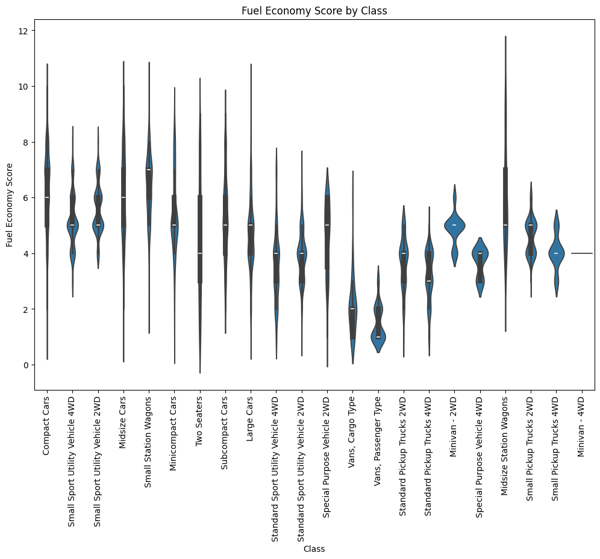

```
Transmission vs. Fuel Economy Score:
                                      mean       std  count
transmission
Auto(AM-S6)                       6.294118  1.242343     85
Auto(AM-S7)                       4.406130  1.463597    261
Auto(AM-S8)                       7.166667  0.752773      6
Auto(AM-S9)                       4.000000       NaN      1
Auto(AM5)                         8.666667  0.516398      6
Auto(AM6)                         7.602740  1.681102     73
Auto(AM7)                         3.713287  2.212711    143
Auto(AM8)                         7.000000  0.000000      2
Auto(AV-S6)                       6.909910  1.108230    111
Auto(AV-S7)                       6.826667  1.223346     75
Auto(AV-S8)                       6.192308  1.132051     26
Automatic (S10)                   3.500000  0.925820      8
Automatic (S4)                    5.800000  0.447214      5
Automatic (S5)                    5.045455  1.328656     44
Automatic (S6)                    5.283710  1.536028   1283
Automatic (S7)                    4.803150  1.380357    127
Automatic (S8)                    4.763825  1.440310    868
Automatic (S9)                    5.172414  0.468201     29
Automatic (variable gear ratios)  7.317269  1.708536    249
Automatic 4-Speed                 4.021053  2.283050     95
Automatic 5-Speed                 3.801587  1.523259    126
Automatic 6-Speed                 4.432268  1.642256    657
Automatic 6Speed                  7.000000       NaN      1
Automatic 7-Speed                 4.483483  1.444932    333
Automatic 8-Speed                 3.987448  0.950370    239
Automatic 9-Speed                 5.085714  0.809965    105
Manual 5-Speed                    6.722222  1.161397    198
Manual 6-Speed                    5.741809  1.654603    763
Manual 7-Speed                    4.835821  0.411833     67
Manual(M7)                        3.333333  2.081666      3
```

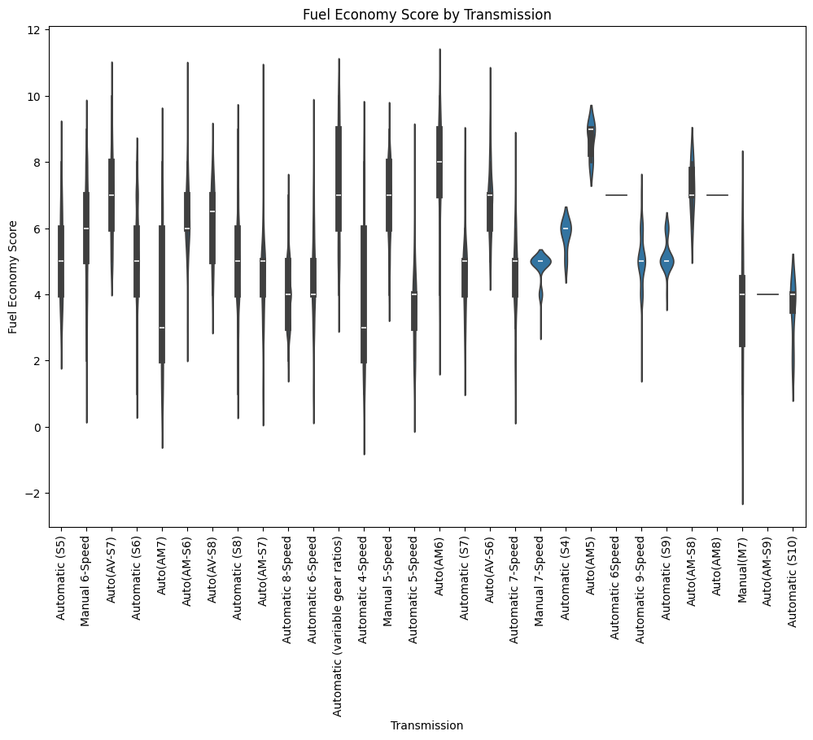

```
Drive vs. Fuel Economy Score:
                             mean       std  count
drive
4-Wheel Drive            4.235736  1.297765    666
All-Wheel Drive          4.869657  1.344501   1427
Front-Wheel Drive        6.621554  1.333406   1995
Part-time 4-Wheel Drive  2.960938  1.037884    128
Rear-Wheel Drive         4.256063  1.543161   1773
```

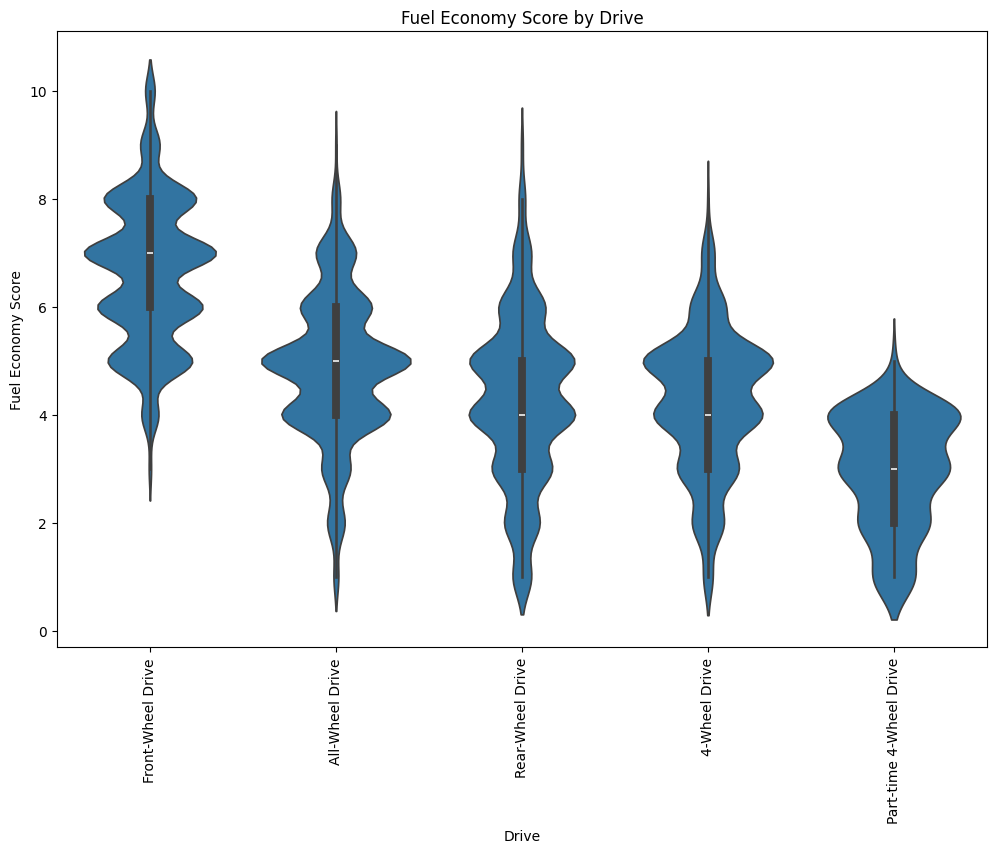

```
Fuel_type vs. Fuel Economy Score:
                                 mean       std  count
fuel_type
CNG                          6.250000  3.500000      4
Diesel                       7.000000  1.258736     78
Gasoline or E85              3.931818  1.530223    440
Gasoline or natural gas      4.500000  0.707107      2
Midgrade                     3.491803  0.673868     61
Premium                      4.804315  1.635677   2642
Premium and Electricity      7.520000  1.686219     25
Premium or E85               4.662921  1.347926     89
Regular                      5.693878  1.707322   2646
Regular Gas or Electricity  10.000000  0.000000      2
```

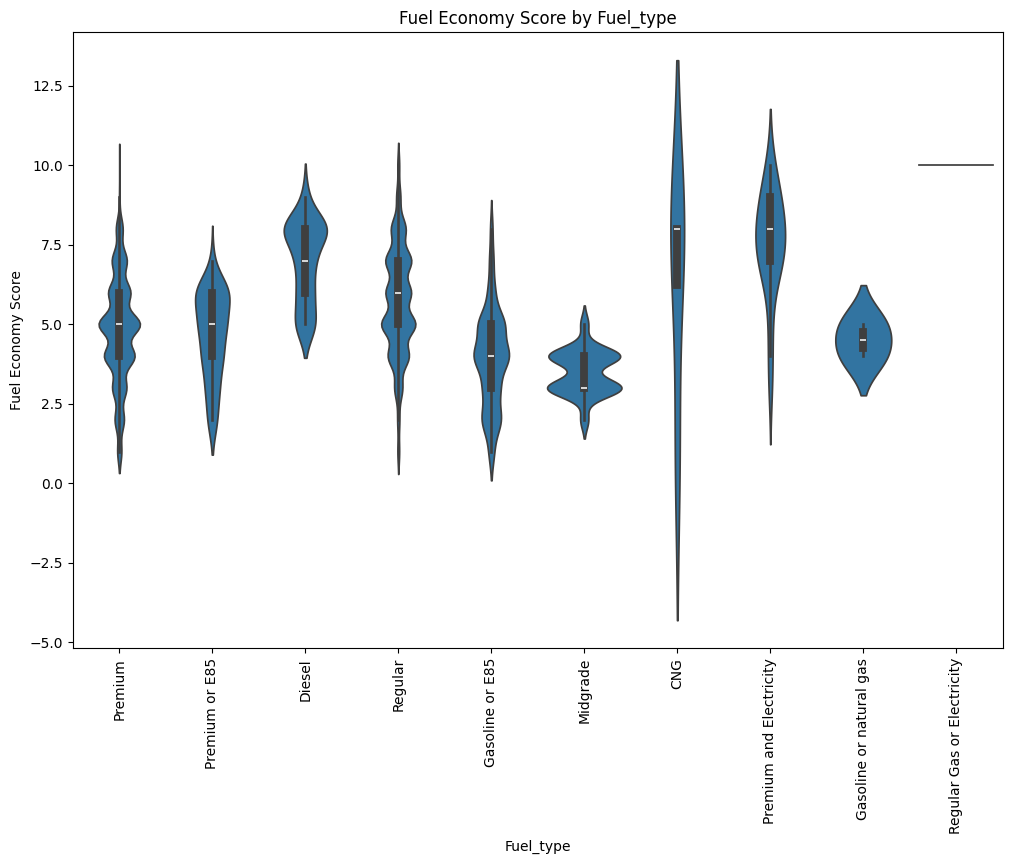

```python
# filter out rows with invalid fuel economy scores
valid_fuel_vehicles = fuel_vehicles[fuel_vehicles['fuel_economy_score'] != -1]
print(f"Number of rows with valid fuel economy scores: {valid_fuel_vehicles.shape[0]}")

#functino to plot and print data statistics
def analyze_and_plot(variable):
    # descriptive statistics
    stats = valid_fuel_vehicles.groupby(variable)['fuel_economy_score'].agg(['mean', 'std', 'count'])
    print(f"\n{variable.capitalize()} vs. Fuel Economy Score:")
    print(stats)

    # Violin plots
    plt.figure(figsize=(12, 8))
    sns.violinplot(x=variable, y='fuel_economy_score', data=valid_fuel_vehicles)
    plt.title(f'Fuel Economy Score by {variable.capitalize()}')
    plt.xticks(rotation=90)
    plt.xlabel(variable.capitalize())
    plt.ylabel('Fuel Economy Score')
    plt.show()

#using the above function
analyze_and_plot('class')
analyze_and_plot('transmission')
analyze_and_plot('drive')
analyze_and_plot('fuel_type')
```

```
                                 class  fuel_economy_score  \
31993                     Compact Cars                   7
31994                     Compact Cars                   6
31995                     Compact Cars                   9
31996  Small Sport Utility Vehicle 4WD                   4
31997  Small Sport Utility Vehicle 2WD                   6

       standardized_FE_score
31993               0.474882
31994              -0.152828
31995               1.730303
31996              -1.179407
31997               0.464010
```

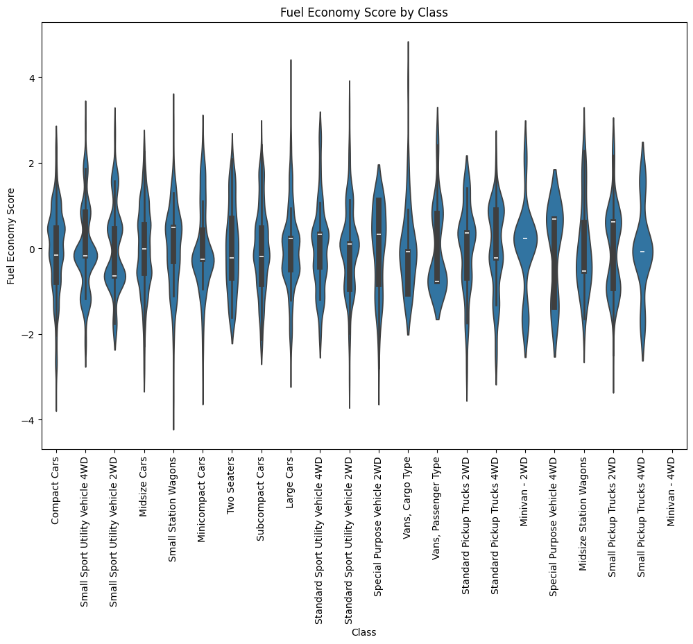

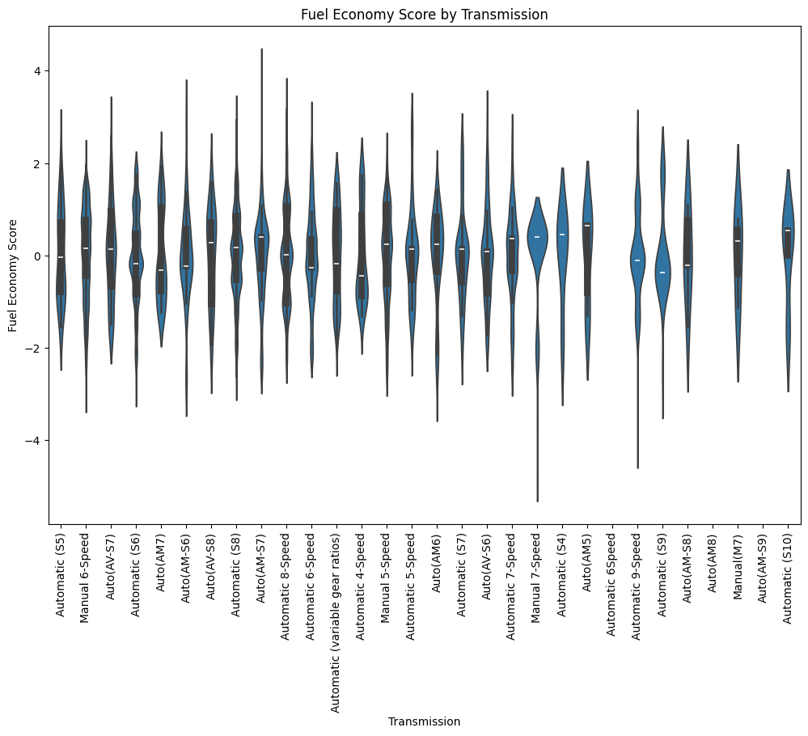

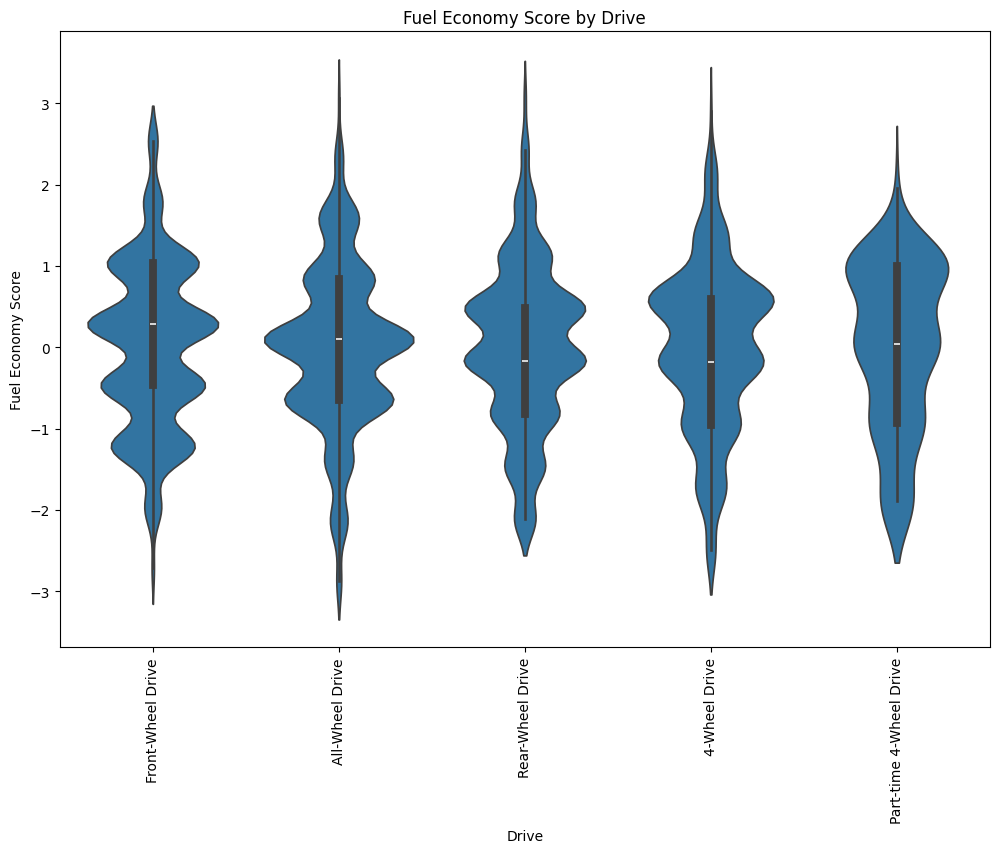

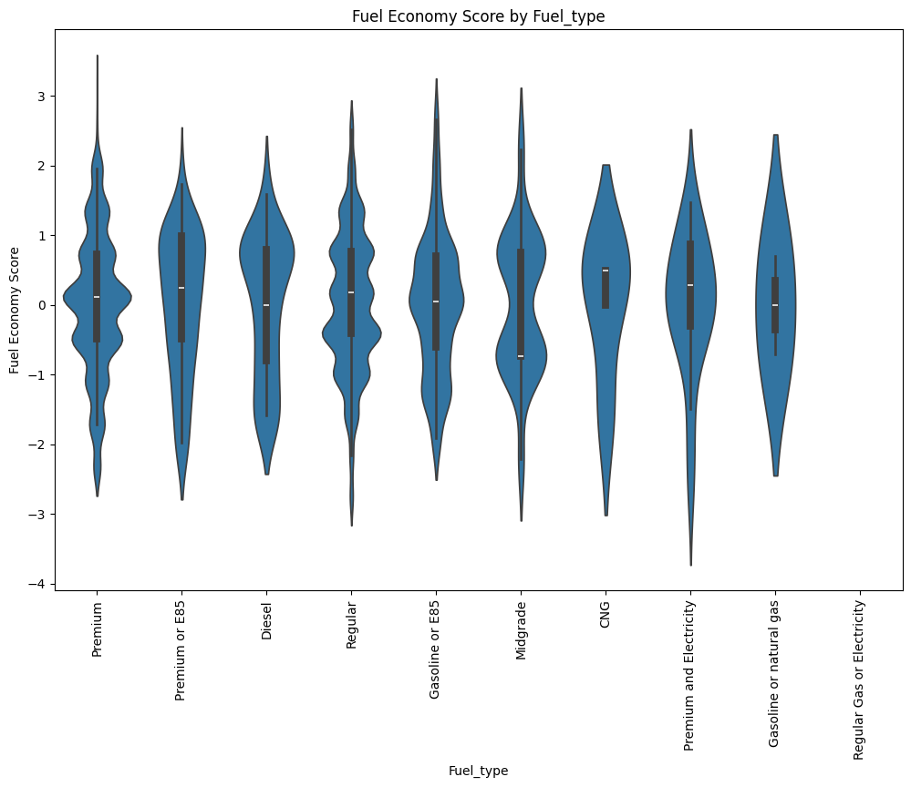

```python
'''normalzing data'''

# function to normalize data by category
def standardize_by_category(df, var):
  df_copy = df[[var, 'fuel_economy_score']].copy()
  means = df_copy.groupby(var)['fuel_economy_score'].transform('mean')
  stds = df_copy.groupby(var)['fuel_economy_score'].transform('std')
  df_copy[f'standardized_FE_score'] = df_copy.groupby(var)['fuel_economy_score'].transform(lambda x: (x - x.mean()) / x.std())
  return df_copy

#using the above function
standard_class = standardize_by_category(valid_fuel_vehicles, 'class')
standard_transmission = standardize_by_category(valid_fuel_vehicles, 'transmission')
standard_drive = standardize_by_category(valid_fuel_vehicles, 'drive')
standard_fuel_type = standardize_by_category(valid_fuel_vehicles, 'fuel_type')

print(standard_class.head())

# function to plot standardized data
def plot_standardized(df, var):
  plt.figure(figsize=(12, 8))
  sns.violinplot(x=var, y='standardized_FE_score', data=df)
  plt.title(f'Fuel Economy Score by {var.capitalize()}')
  plt.xticks(rotation=90)
  plt.xlabel(var.capitalize())
  plt.ylabel('Fuel Economy Score')
  plt.show()

#using the above function
plot_standardized(standard_class, 'class')
plot_standardized(standard_transmission, 'transmission')
plot_standardized(standard_drive, 'drive')
plot_standardized(standard_fuel_type, 'fuel_type')
```

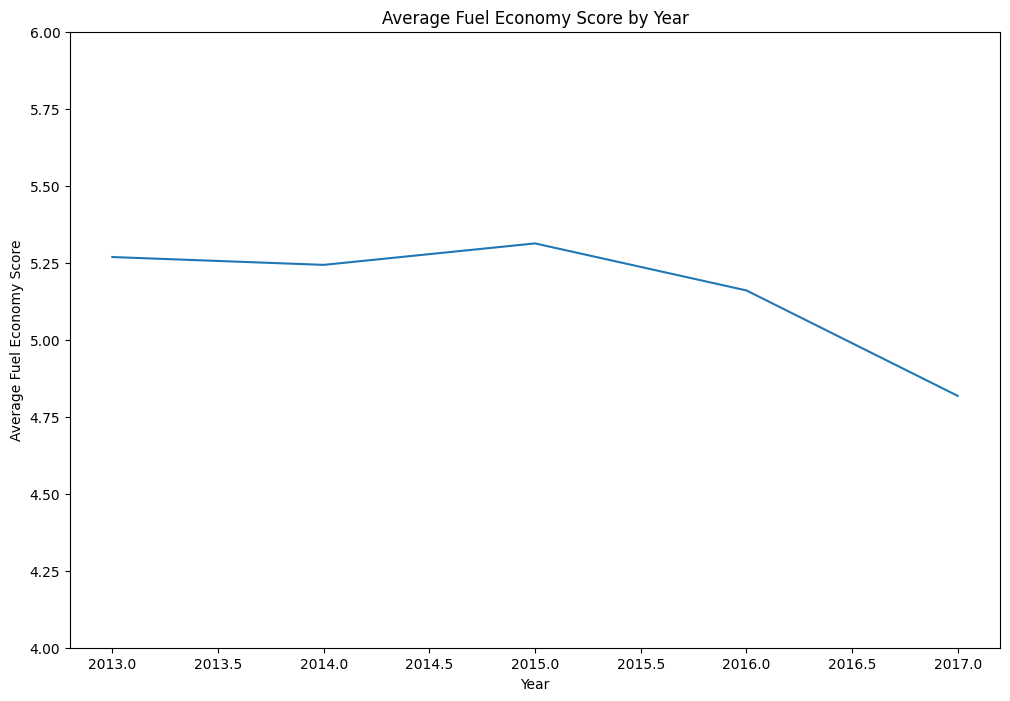

```python
# calculate an plot average fuel economy by year
avg_fuel_economy_by_year = valid_fuel_vehicles.groupby('year')['fuel_economy_score'].mean().reset_index()


plt.figure(figsize=(12, 8))
sns.lineplot(data=avg_fuel_economy_by_year, x='year', y='fuel_economy_score')
plt.title('Average Fuel Economy Score by Year')
plt.xlabel('Year')
plt.ylabel('Average Fuel Economy Score')
plt.ylim(4, 6)
plt.show()
```

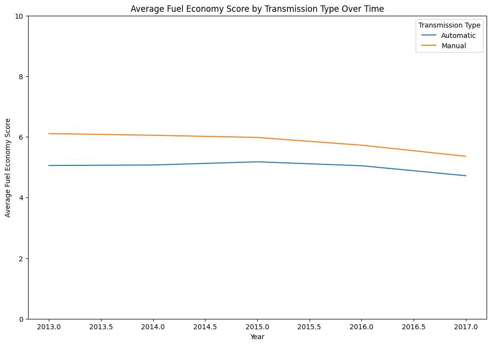

```python
# combine transmission categories
valid_fuel_vehicles.loc[:, 'transmission'] = valid_fuel_vehicles['transmission'].str.lower()
valid_fuel_vehicles.loc[:, 'transmission'] = valid_fuel_vehicles['transmission'].replace({
    r'auto.*': 'Automatic',
    r'.*manual.*': 'Manual'
}, regex=True)

# calculate and plot average fuel economy by year and transmission type

avg_fuel_economy_by_trans_year = valid_fuel_vehicles.groupby(['year', 'transmission'])['fuel_economy_score'].mean().reset_index()

plt.figure(figsize=(12, 8))
sns.lineplot(data=avg_fuel_economy_by_trans_year, x='year', y='fuel_economy_score', hue='transmission')
plt.title('Average Fuel Economy Score by Transmission Type Over Time')
plt.xlabel('Year')
plt.ylabel('Average Fuel Economy Score')
plt.ylim(0, 10)
plt.legend(title='Transmission Type')
plt.show()
```

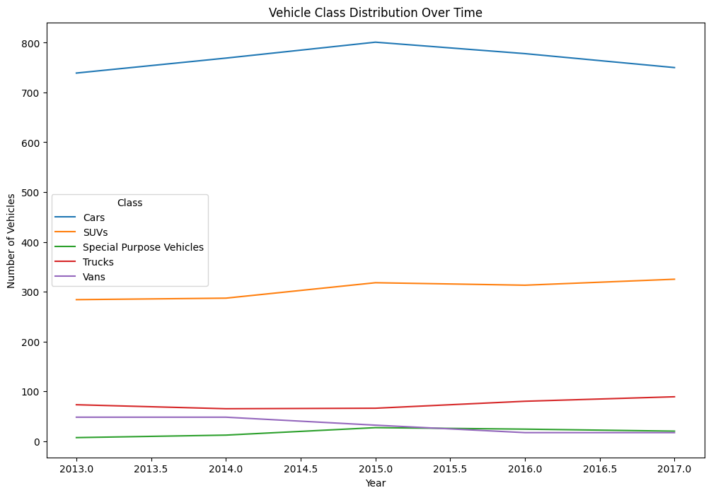

```python
# combine vehicle classes
class_replacements = {
    'Compact Cars': 'Cars',
    'Large Cars': 'Cars',
    'Midsize Cars': 'Cars',
    'Subcompact Cars': 'Cars',
    'Two Seaters': 'Cars',
    'Small Station Wagons': 'Cars',
    'Midsize Station Wagons': 'Cars',
    'Minicompact Cars': 'Cars',
    'Minivan - 2WD': 'Vans',
    'Minivan - 4WD': 'Vans',
    'Vans, Cargo Type': 'Vans',
    'Vans, Passenger Type': 'Vans',
    'Small Sport Utility Vehicle 2WD': 'SUVs',
    'Small Sport Utility Vehicle 4WD': 'SUVs',
    'Standard Sport Utility Vehicle 2WD': 'SUVs',
    'Standard Sport Utility Vehicle 4WD': 'SUVs',
    'Standard Pickup Trucks 2WD': 'Trucks',
    'Standard Pickup Trucks 4WD': 'Trucks',
    'Small Pickup Trucks 2WD': 'Trucks',
    'Small Pickup Trucks 4WD': 'Trucks',
    'Special Purpose Vehicle 2WD': 'Special Purpose Vehicles',
    'Special Purpose Vehicle 4WD': 'Special Purpose Vehicles'
}
valid_fuel_vehicles.loc[:, 'class'] = valid_fuel_vehicles['class'].replace(class_replacements)

# calculate and plot the distribution of vehicle classes over time
vehicle_class_distribution = valid_fuel_vehicles.groupby(['year', 'class']).size().unstack().fillna(0)

plt.figure(figsize=(12, 8))
vehicle_class_distribution.plot(kind='line', figsize=(12, 8))
plt.title('Vehicle Class Distribution Over Time')
plt.xlabel('Year')
plt.ylabel('Number of Vehicles')
plt.legend(title='Class')
plt.show()
```

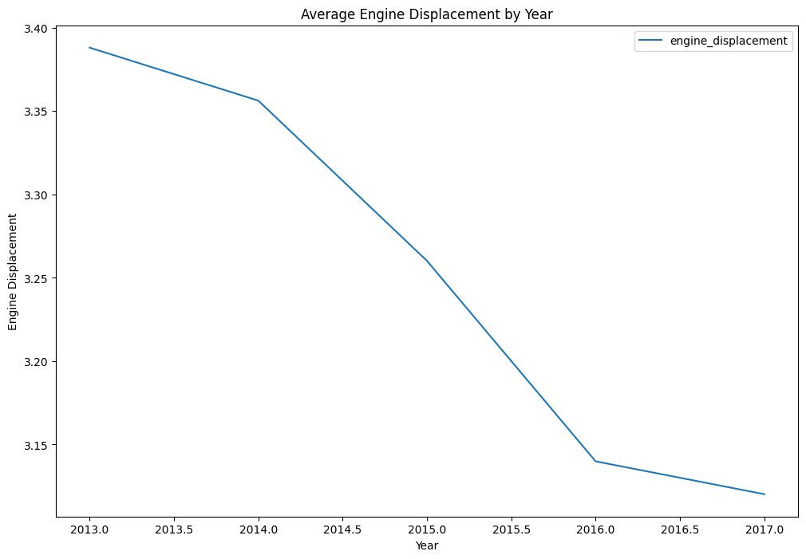

```python
#calculate and plot average engine displacement by year

avg_engine_displacement_by_year = valid_fuel_vehicles.groupby('year')['engine_displacement'].mean().reset_index()
avg_engine_displacement_by_year.plot(kind='line', x='year', y='engine_displacement', figsize=(12, 8))
plt.title('Average Engine Displacement by Year')
plt.xlabel('Year')
plt.ylabel('Engine Displacement')
plt.show()
```

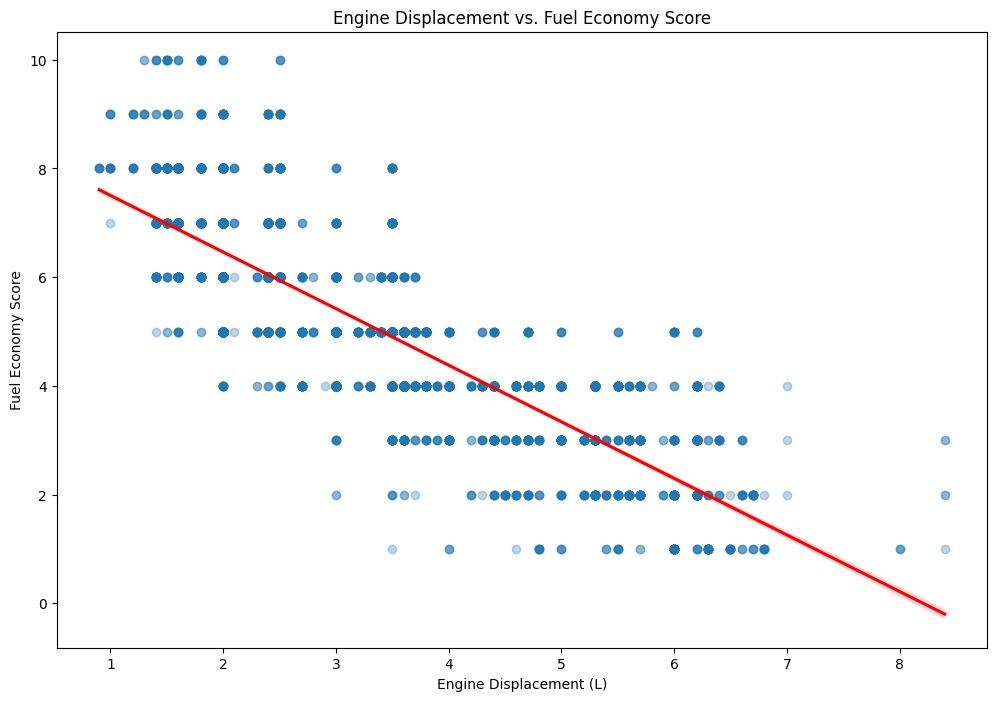

```python
# scatter plot of engine displacement vs. fuel economy score
plt.figure(figsize=(12, 8))
sns.regplot(x='engine_displacement', y='fuel_economy_score', data=valid_fuel_vehicles, scatter_kws={'alpha':0.3}, line_kws={'color':'red'})
plt.title('Engine Displacement vs. Fuel Economy Score')
plt.xlabel('Engine Displacement (L)')
plt.ylabel('Fuel Economy Score')
plt.show()
```

We used a linear regression model with stochastic gradient descent to predict the fuel economy scores of a vehicle. We selected relevant data such as year, make, model, class, drive, transmission, engine cylinders, and engine displacement. Then we split the data into training and test data to test the output predictions of our model later. We scaled the numeric features such as year, engine cylinders, and engine displacement, using StandardScalar. For the categorical variables, we used one hot encoding (make, model, class, drive, and transmission). After using the SGDRegressor to train the mode, we predicted the scores on the test set. When we calculated the mean squared error and r^2 scores of the model, we got a mse of 0.5387 and a r^2 score of 0.8206. The mse score shows the average squared difference between the actual and predicted fuel economy scores. Since this MSE value is low, it indicates a good fit. An r^2 score closer to 1 indicates a better fit.

You can find more information in the [Scikit-Learn documentation](https://scikit-learn.org/stable/tutorial/index.html).

```python
'''
ML
'''
# replace specific vehicle classes with broader categories
valid_fuel_vehicles.loc[:, 'class'] = valid_fuel_vehicles['class'].replace(class_replacements)

features = ['year', 'make', 'model', 'class', 'drive', 'transmission', 'engine_cylinders', 'engine_displacement']
target = 'fuel_economy_score'

X = valid_fuel_vehicles[features]
y = valid_fuel_vehicles[target]

# split the data into train and test
X_train, X_test, y_train, y_test = train_test_split(X, y, test_size=0.2, random_state=42)
X_test_original = X_test.copy()

numeric_features = ['year', 'engine_cylinders', 'engine_displacement']
scaler = StandardScaler()
X_train_numeric = scaler.fit_transform(X_train[numeric_features])
X_test_numeric = scaler.transform(X_test[numeric_features])

# one hot encoding categorical features
categorical_features = ['make', 'model', 'class', 'drive', 'transmission']
encoder = OneHotEncoder(handle_unknown='ignore')
X_train_categorical = encoder.fit_transform(X_train[categorical_features])
X_test_categorical = encoder.transform(X_test[categorical_features])

X_train_processed = np.hstack((X_train_numeric, X_train_categorical.toarray()))
X_test_processed = np.hstack((X_test_numeric, X_test_categorical.toarray()))

# train the SGDRegressor model
sgd_regressor = SGDRegressor(max_iter=1000, tol=1e-3, random_state=42)
sgd_regressor.fit(X_train_processed, y_train)

# predict on test set
y_pred = sgd_regressor.predict(X_test_processed)

# evaluate model
mse = mean_squared_error(y_test, y_pred)
r2 = r2_score(y_test, y_pred)

print(f"Mean Squared Error: {mse}")
print(f"R^2 Score: {r2}")
```

```
Mean Squared Error: 0.5387260733177642
R^2 Score: 0.8206003081027947
```

```python
# print predicted vs. actual
results = pd.DataFrame({
    'Actual': y_test,
    'PREDICTED': y_pred
})

results = pd.concat([results.reset_index(drop=True), X_test_original.reset_index(drop=True)], axis=1)
print(results.head())
```

```
   Actual  PREDICTED  year        make                  model class  \
0       7   6.349146  2015        MINI  Cooper S Paceman All4  Cars
1       4   4.325904  2015  Land Rover            Range Rover  SUVs
2       3   2.850913  2014  Land Rover      Range Rover Sport  SUVs
3       5   5.143573  2017     Porsche        911 Targa 4 GTS  Cars
4       5   5.199509  2015     Porsche            911 Targa 4  Cars

             drive transmission  engine_cylinders  engine_displacement
0  All-Wheel Drive       Manual               4.0                  1.6
1    4-Wheel Drive    Automatic               6.0                  3.0
2    4-Wheel Drive    Automatic               8.0                  5.0
3    4-Wheel Drive    Automatic               6.0                  3.0
4    4-Wheel Drive    Automatic               6.0                  3.4
```

## Interpretation

Based on our observations throughout our analysis and modeling, we found these trends:

Based on our analysis and model predictions, we can draw several conclusions:

To build on our findings, further research could involve finding more recent data, investigating the impact of new technologies on fuel economy scores, analyzing seasonal variations and their effects, as well as exploring the impact of different driving conditions and behaviors on fuel economy.